# 6 Reasons Why You Should Start Using R

# Reason #2 - The IDE

Pure R:

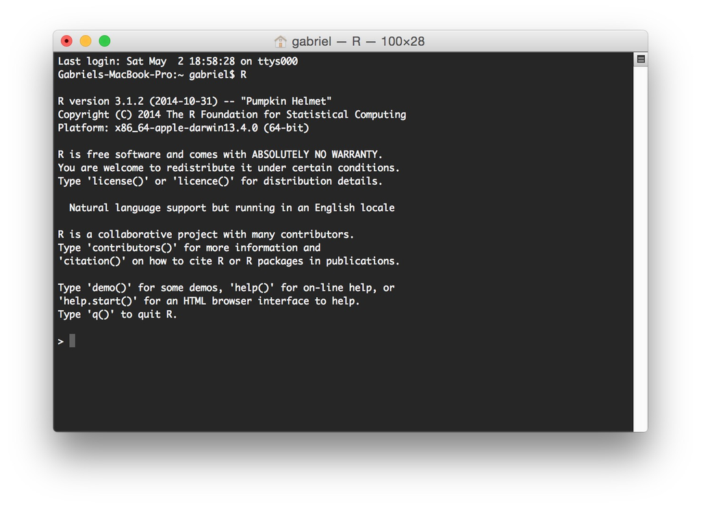

# Reason #2 - The IDE

RStudio:

[figure not shown]

# Reason #3 - Data Manipulation

type:section

# Reason #3 - Data Manipulation

### Which Product is the Most Wanted?

|  | colour.name | colour.code | productid | skuid |
| --- | --- | --- | --- | --- |
| 57 | NEGRO | #2c2b31 | 6351140127 | 635114012799 |
| 58 | NEGRO | #2c2b31 | 6351120125 | 635112012599 |
| 59 | GRANATE | #FF00FF | 6430610162 | 643061016269 |
| 60 | PERLA | #BCBBC0 | 1825939990 | 8433815103871 |
| 61 | PERLA | #BCBBC0 | 1825939990 | 8433815123107 |
| 62 | NEGRO | #2c2b31 | 6103920029 | 8433815103444 |
| 63 | INDIGO | #517bd5 | 5256939960 | 525693996045 |
| 64 | AZUL CIELO | #90a6d2 | 5256839716 | 525683971641 |

# Reason #3 - Data Manipulation

incremental:true

## Which Product is the Most Wanted?

### **Tapply**

```r
# the number of sales per product
tries <- tapply(ds1$skuid, ds1$productid, length)
```

```r
# the product with more tries
tries[which(tries == max(tries))]
```

```
5860769906
        35
```

# Reason #3 - Data Manipulation

incremental:true

### Which Combination “Product + Color”?

```r
# number of sales per product and color
tries <- tapply(ds1$skuid, ds1[, c("productid", "colour.code")], length)

# the product with more sales
ind <- which(tries == max(tries, na.rm = TRUE), arr.ind=TRUE)
```

[output not shown]

# Reason #3 - Data Manipulation

# Reason #3 - Data Manipulation

|  | Country.Name | Country.Code | Indicator.Name | Indicator.Code | X1960 |
| --- | --- | --- | --- | --- | --- |
| 23 | Bosnia and Herzegovina | BIH | Internet users (per 100 people) | IT.NET.USER.P2 | NA |

|  | Country.Name | Country.Code | Region | IncomeGroup | SpecialNotes |
| --- | --- | --- | --- | --- | --- |
| 24 | Bosnia and Herzegovina | BIH | Europe & Central Asia | Upper middle income | Based on official government statistics for chain linked series; the new reference year is 2010. |

# Reason #3 - Data Manipulation

incremental:true

## What is the European Country with the Greatest % of Users in 2013?

### **Merge**

```r
ds2 <- merge(ds2.p1, ds2.p2, by = "Country.Code")
```

### **Subset**

```r
europeans <- subset(ds2, Region == "Europe & Central Asia")
```

```r
order.ind <- order(as.numeric(europeans$X2013), decreasing = T)
```

```r
europeans[order.ind, ]
```

# Reason #3 - Data Manipulation

|  | Country.Code | Country.Name.x | X2013 |
| --- | --- | --- | --- |
| 105 | ISL | Iceland | 96.5468 |
| 168 | NOR | Norway | 95.0534 |
| 212 | SWE | Sweden | 94.7836 |
| 57 | DNK | Denmark | 94.6297 |
| 5 | AND | Andorra | 94.0000 |
| 166 | NLD | Netherlands | 93.9564 |
| 128 | LIE | Liechtenstein | 93.8000 |
| 134 | LUX | Luxembourg | 93.7765 |
| 73 | FIN | Finland | 91.5144 |
| 139 | MCO | Monaco | 90.7000 |

# Reason #4 - Data Visualization

type:section

# Reason #4 - Data Visualization

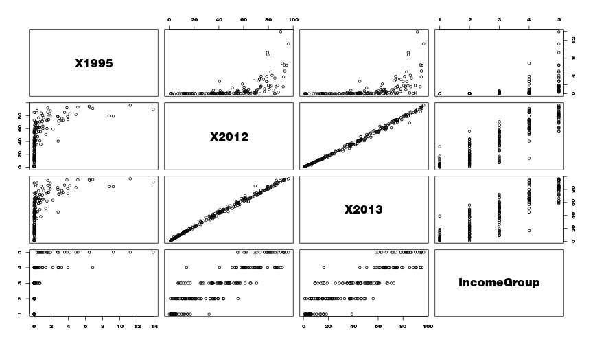

```r
pairs(ds2.obs)
```

# Reason #4 - Data Visualization

### 3. Internet services around the world

| Region | Country | Technology | Product.name | Downstream.bandwidth | Downstream.units |
| --- | --- | --- | --- | --- | --- |
| Asia | Afghanistan | ADSL | DSL Shared Connection | 128 | Kbps |
| Asia | Afghanistan | ADSL | DSL Shared Connection | 256 | Kbps |
| Asia | Afghanistan | ADSL | DSL Shared Connection | 512 | Kbps |
| Asia | Afghanistan | ADSL | DSL Shared Connection | 1024 | Kbps |

# Reason #4 - Data Visualization

## How is the Internet Service in Spain?

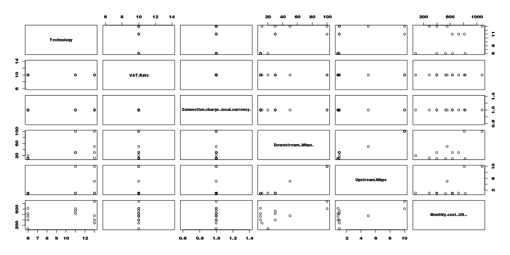

```r
pairs(subset(ds3, Technology != "" & Date.tariff.recorded == "2012Q3" & Country.Name.x == "Spain")[cols])
```

# Reason #4 - Data Visualization

## How is the Internet Service in USA?

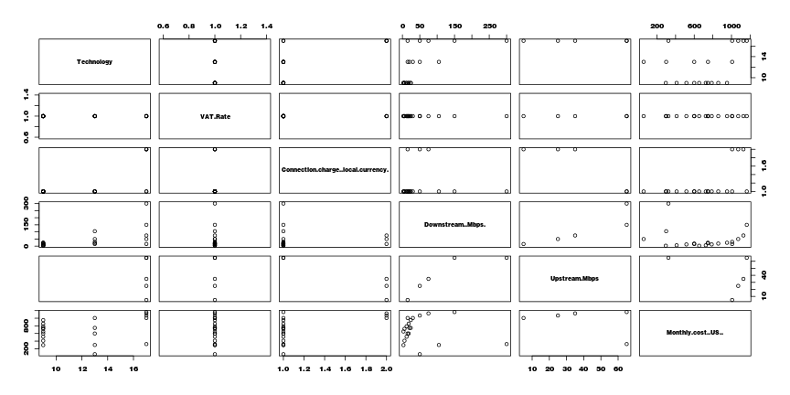

```r
pairs(subset(ds3, Technology != "" & Date.tariff.recorded == "2012Q3" & Country.Name.x == "United States")[cols])
```

# Reason #4 - Data Visualization

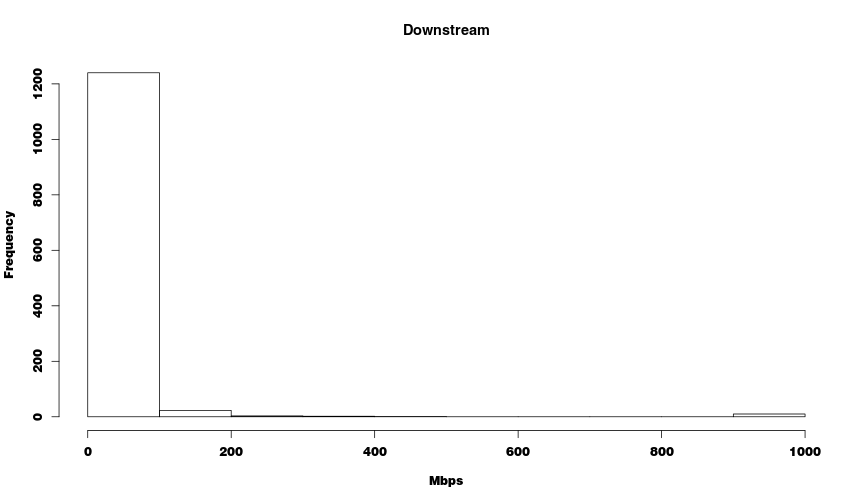

```r
hist(ds3$Downstream..Mbps., xlab = "Mbps", main = "Downstream")
```

# Reason #4 - Data Visualization

### 4. Activities in an online course

```
{
    "username": "---",
    "event_type": "load_video",
    "ip": "---",
    "agent": "Mozilla/5.0 (Windows NT 6.0) AppleWebKit/537.36 (KHTML, like Gecko) Chrome/37.0.2062.124 Safari/537.36",
    "host": "www.ucatx.cat",
    "session": "f689d6cd57bb0f68a1a8759fd251088d",
    "event": "{\"id\":\"i4x-UPF-C01-video-7ebca4d2e7164f6d944875cede5aa753\",\"code\":\"Eysn011TDjg\"}",
    "event_source": "browser",
    "context": {
        "username": "---",
        "user_id": 149,
        "ip": "---",
        "org_id": "UPF",
        "agent": "Mozilla/5.0 (Windows NT 6.0) AppleWebKit/537.36 (KHTML, like Gecko) Chrome/37.0.2062.124 Safari/537.36",
        "host": "www.ucatx.cat",
        "session": "f689d6cd57bb0f68a1a8759fd251088d",
        "course_id": "UPF/C01/2014",
        "path": "/event"
    },
    "time": "2014-09-29T17:19:25.295450+00:00",
    "page": "---"
}
```

# Reason #4 - Data Visualization

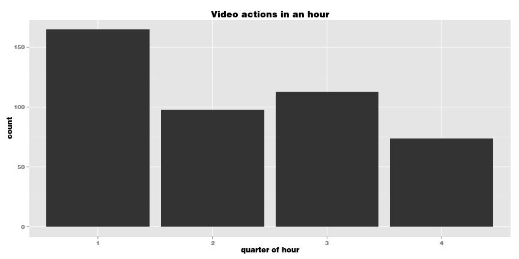

```r
qplot(data = subset(ds4,
                event_source == "browser" & # events from browser
                grep("video", event_type) & # only video playings
                !is.na(time)), # with information about the time
      x = as.character(floor(minute(time) / 15)+1), # split the hour
      xlab = "quarter of hour", main = "Video actions in an hour")
```

# Reason #4 - Data Visualization

```r
qplot(data = subset(ds4,
                event_source == "browser" & # events from browser
                grep("video", event_type) & # only video playings
                !is.na(time)), # with information about the time
      x = as.character(floor(minute(time) / 15) + 1), # split the hour
      xlab = "quarter of hour", main = "Video actions per user",
      facets = username ~ .)
```

# Reason #4 - Data Visualization

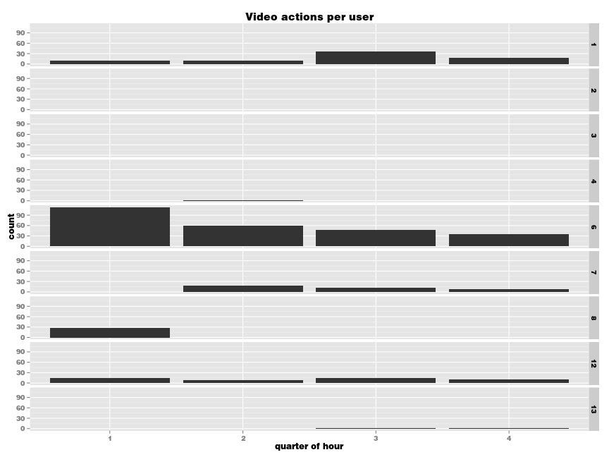

# Reason #4 - Data Visualization

```r
qplot(data = subset(ds4,
                event_source == "browser" & # events from browser
                grep("video", event_type) & # only video playings
                !is.na(time) & # with information about the time
                username == "6"),
      x = as.character(floor(minute(time) / 15) + 1), # split the hour
      xlab = "quarter of hour", main = "Video actions of user #6",
      fill = event_type)
```

# Reason #4 - Data Visualization

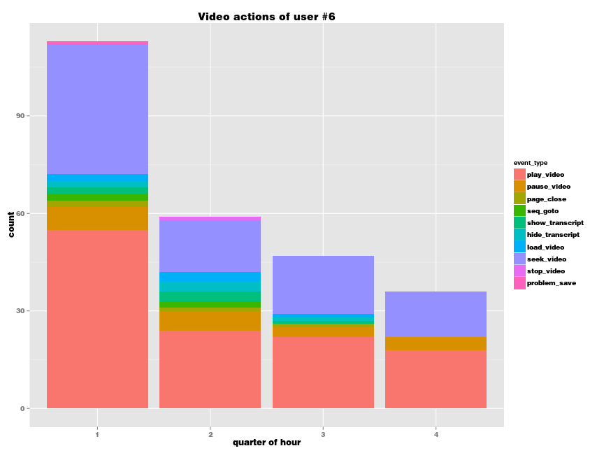

# Reason #4 - Data Visualization

### 5. Social media users

| age | gender | residence | religion | maritalstatus | community |
| --- | --- | --- | --- | --- | --- |
| 26-35 | female | Boca Raton | Muslim | Single | f |
| 18-25 | female | Boca Raton | Jewish | Single | g |
| 66-75 | male | Santa Barbara | Hindu | Widowed | d |
| 26-35 | female | Boca Raton | Muslim | Single | f |
| 56-65 | female | Palo Alto | Jewish | Divorced | e |
| 26-35 | female | Boca Raton | Muslim | Single | f |

*11 different characteristics about each user **plus their community***

# Reason #4 - Data Visualization

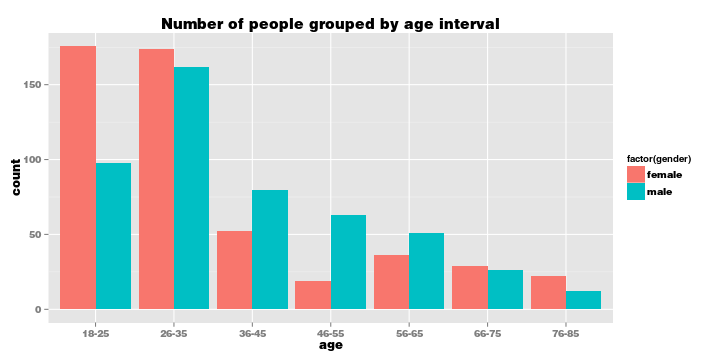

```r
qplot(age,
      data = ds5,
      fill = factor(gender),
      position="dodge",
      main = "Number of people grouped by age interval")
```

# Reason #5 - Predictions

type:section

# Reason #5 - Predictions

| age | gender | residence | religion | maritalstatus | community |
| --- | --- | --- | --- | --- | --- |
| 26-35 | female | Boca Raton | Muslim | Single | 5 |
| 18-25 | female | Boca Raton | Jewish | Single | 6 |
| 66-75 | male | Santa Barbara | Hindu | Widowed | 3 |
| 26-35 | female | Boca Raton | Muslim | Single | 5 |
| 56-65 | female | Palo Alto | Jewish | Divorced | 4 |
| 26-35 | female | Boca Raton | Muslim | Single | 5 |
| 26-35 | female | Norfolk | Buddhist | Divorced | 2 |
| 18-25 | female | Boca Raton | Christian | Single | 8 |
| 46-55 | male | Santa Barbara | Christian | Single | 4 |
| 56-65 | male | Santa Barbara | Hindu | Widowed | 9 |

# Reason #5 - Predictions

### Training

| age | gender | residence | religion | maritalstatus | community |
| --- | --- | --- | --- | --- | --- |
| 26-35 | female | Boca Raton | Muslim | Single | f |
| 18-25 | female | Boca Raton | Jewish | Single | g |
| 66-75 | male | Santa Barbara | Hindu | Widowed | d |
| 26-35 | female | Boca Raton | Muslim | Single | f |
| 56-65 | female | Palo Alto | Jewish | Divorced | e |
| 26-35 | female | Boca Raton | Muslim | Single | f |
| 26-35 | female | Norfolk | Buddhist | Divorced | c |
| 18-25 | female | Boca Raton | Christian | Single | i |

# Reason #5 - Predictions

### Training

| age | gender | residence | religion | maritalstatus | community |
| --- | --- | --- | --- | --- | --- |
| 26-35 | female | Boca Raton | Muslim | Single | f |
| 18-25 | female | Boca Raton | Jewish | Single | g |
| 66-75 | male | Santa Barbara | Hindu | Widowed | d |
| 26-35 | female | Boca Raton | Muslim | Single | f |
| 56-65 | female | Palo Alto | Jewish | Divorced | e |
| 26-35 | female | Boca Raton | Muslim | Single | f |
| 26-35 | female | Norfolk | Buddhist | Divorced | c |
| 18-25 | female | Boca Raton | Christian | Single | i |

### Testing

| age | gender | residence | religion | maritalstatus | community |
| --- | --- | --- | --- | --- | --- |
| 46-55 | male | Santa Barbara | Christian | Single | e |
| 56-65 | male | Santa Barbara | Hindu | Widowed | j |

# Reason #5 - Predictions

### **Data Partition**

```r
# create 2 partitions
indicesTrain <- createDataPartition(y = ds5$community, p=0.8, list=FALSE)

#for training
training <- ds5[indicesTrain,]

#for testing the predictions
testing <- ds5[-indicesTrain,]
```

# Reason #5 - Predictions

## Can we Discover a Person’s Community based on their Interests?

### **Cross validation**

```r
model <- train(community ~ ., data = training, method = "rf",
               # for the cross validation
               trControl=trainControl(method="cv",number=5),
               # allow proximity calculation -- used to plot importance
                prox=TRUE)
```

```r
# test the model
predictions <- predict(model, testing)

# show results
confusionMatrix(predictions, testing$community)
```

# Reason #5 - Predictions

## Results by Try

```
          Reference
Prediction  a  b  c  d  e  f  g  h  i  j
         a 40  0  1  0  0  0  0  0  0  0
         b  1 33  0  0  1  3  0  0  1  0
         c  0  0 41  0  0  2  0  0  0  0
         d  1  0  0 19  0  0  0  1  0  0
         e  0  0  0  0 14  0  0  0  0  0
         f  1  1  0  0  0 26  0  0  0  0
         g  0  0  0  0  0  0  4  0  0  0
         h  0  0  0  0  0  0  0  0  0  0
         i  0  0  0  0  1  0  0  0  4  0
         j  0  0  0  0  0  0  0  0  0  1
```

# Reason #5 - Predictions

## Results by Class

```
         Sensitivity Specificity Pos Pred Value Neg Pred Value  Prevalence
Class: a   0.9302326   0.9934641      0.9756098      0.9806452 0.219387755
Class: b   0.9705882   0.9629630      0.8461538      0.9936306 0.173469388
Class: c   0.9761905   0.9870130      0.9534884      0.9934641 0.214285714
Class: d   1.0000000   0.9887006      0.9047619      1.0000000 0.096938776
Class: e   0.8750000   1.0000000      1.0000000      0.9890110 0.081632653
Class: f   0.8387097   0.9878788      0.9285714      0.9702381 0.158163265
Class: g   1.0000000   1.0000000      1.0000000      1.0000000 0.020408163
Class: h   0.0000000   1.0000000            NaN      0.9948980 0.005102041
Class: i   0.8000000   0.9947644      0.8000000      0.9947644 0.025510204
Class: j   1.0000000   1.0000000      1.0000000      1.0000000 0.005102041
         Detection Rate Detection Prevalence Balanced Accuracy
Class: a    0.204081633          0.209183673         0.9618483
Class: b    0.168367347          0.198979592         0.9667756
Class: c    0.209183673          0.219387755         0.9816017
Class: d    0.096938776          0.107142857         0.9943503
Class: e    0.071428571          0.071428571         0.9375000
Class: f    0.132653061          0.142857143         0.9132942
Class: g    0.020408163          0.020408163         1.0000000
Class: h    0.000000000          0.000000000         0.5000000
Class: i    0.020408163          0.025510204         0.8973822
Class: j    0.005102041          0.005102041         1.0000000
```

# Reason #5 - Predictions

## Overall Results

- Accuracy : 0.9285714
- Kappa : 0.9142178
- AccuracyLower : 0.8830584
- AccuracyUpper : 0.9604014
- AccuracyNull : 0.2193878
- AccuracyPValue : 3.539296e-101
- McnemarPValue : NaN

# Reason #5 - Predictions

## Can we Know Which are the Most Relevant Variables?

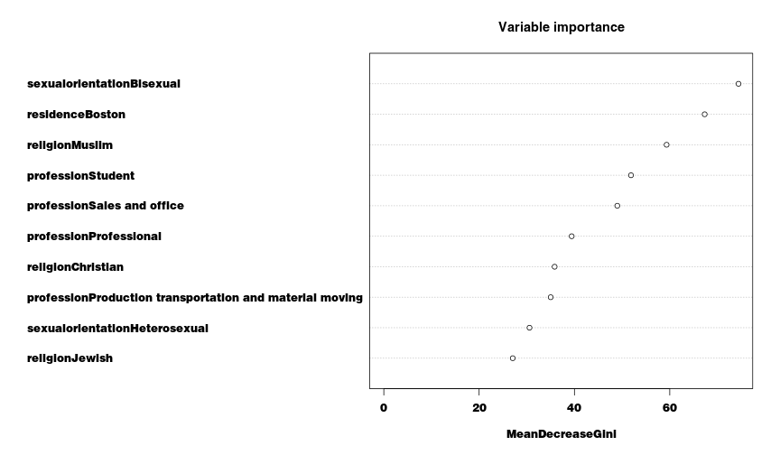

```r
# plot the variable importance
varImpPlot(model$finalModel, n.var = 10, main ="Variable importance")
```

# Reason #6 - Dissemination of Results

type:section

# Reason #6 - Dissemination of Results

- **Reports**

# Reason #6 - Dissemination of Results

- Reports
- **Applications**

# Reason #6 - Dissemination of Results

- Reports
- Applications
- **Presentations**

# Why You Should Start Using R

1. Community
2. The IDE
3. Data Manipulation
4. Data Visualization
5. Predictions
6. Dissemination of Results

# References

D. F. Nettleton, “Generating synthetic online social network graph data and topologies,” 3rd Workshop on Graph-based Technologies and Applications (Graph-TA), UPC, Barcelona, Spain, March 18-th 2015.

# Special Thanks

- [Anna Carreras](https://scholar.google.es/citations?user=wbD9AGgAAAAJ)
- [Manuel Palacin](http://www.nets.upf.edu/node/314)
- [Albert Domingo](https://scholar.google.es/citations?user=rlGr0TwAAAAJ)
- [Miquel Oliver](https://scholar.google.es/citations?user=KswY7uUAAAAJ)
- [David Nettleton](https://scholar.google.com/citations?user=bnS_CxMAAAAJ)

# Why You Should Start Using R

1. Community
2. The IDE
3. Data Manipulation
4. Data Visualization
5. Predictions
6. Dissemination of Results